# Calibration Workshop

Zoe Rennie, Sarah Lam

2023-05-09

### Function output using combined performance metric on Sagehen data

```r
sager <- read.table(here("data", "sager.txt"), header=T)
sager = sager %>% mutate(date = paste(day,month,year, sep="/"))
sager$date = as.Date(sager$date,"%d/%m/%Y")

mme_corcoeff <- function(obs, model, wy, month){
new_frame <- cbind.data.frame(obs,model, wy, month)
monthly_means <- new_frame %>%
  #group by water year and month
  group_by(wy, month) %>%
  # take mean of model est. and observed values by month by water year
 summarize(mean_model=mean(model), mean_obs=mean(obs))
mean_monthly_error <- monthly_means %>%
  #take difference between mean model and mean obs values
  mutate(diff=mean_model-mean_obs) %>%
  ungroup()
mean_monthly_error <- abs(mean(mean_monthly_error$diff))
correlation <- cor(monthly_means$mean_model, monthly_means$mean_obs)
combined = .5*mean_monthly_error+ .5*correlation
return(combined)
}
mme_corcoeff(sager$obs, sager$model, sager$wy, sager$month)
```

```
## [1] 0.5420178
```

We chose this metric because firstly, average monthly error seemed like an intuitive and interesting way to compare the accuracy of the model’s predictions against observed values. Moreover, we felt that the correlation between the model generated and observed values would also serve to represent how accurately the model was able to predict values. Thus, we thought it was logical to combine these two metrics to form a performance metric in order to assess this model.

### Apply function to msage set

```r
#Calibration
msage = read.table(here("data","sagerm.txt"), header=T)
nsim = ncol(msage)
snames = sprintf("S%d",seq(from=1, to=nsim))
colnames(msage)=snames
msage$date = sager$date
msage$month = sager$month
msage$year = sager$year
msage$day = sager$day
msage$wy = sager$wy
msage = left_join(msage, sager[,c("obs","date")], by=c("date"))
msagel = msage %>% pivot_longer(cols=!c(date, month, year, day,wy), names_to="run", values_to="flow")

short_msage = subset(msage, wy < 1975)
# compute performance measures for output from all parameters
res = short_msage %>% select(!c("date","month","year","day","wy","obs")) %>%
      map_dbl(mme_corcoeff, short_msage$obs, short_msage$wy, short_msage$month)

head(res)
```

```
##        S1        S2        S3        S4        S5        S6
## 0.4642379 0.4890661 0.7895366 0.6707126 0.6516440 0.7465734
```

```r
best <- res[which.max(res)]
worst <- res[which.min(res)]
```

##### Best parameter set

```r
best
```

```
##       S95
## 0.8290643
```

```r
res_df = short_msage %>% select(!c("date","month","year","day","wy","obs")) %>%
      map_df(mme_corcoeff, short_msage$obs, short_msage$wy, short_msage$month)
```

##### Worst parameter set

```r
worst
```

```
##        S1
## 0.4642379
```

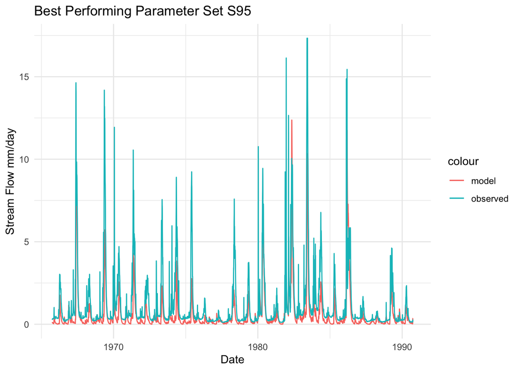

```r
# graph results of best model compared to observed data

ggplot(msage, aes(date, S95))+ geom_line(aes(col = "model"))+
  geom_line(aes(date, obs, col = "observed")) +
  labs(x = "Date",
       y = "Stream Flow mm/day") + ggtitle("Best Performing Parameter Set S95") + theme_minimal()
```

### Extra Credit Section

#### Select acceptable outcomes

```r
#convert to data frame
res_2 <- as.data.frame(res)
res_df <- cbind.data.frame(res=res_2$res, sim=paste0("S", 1:101))

#reorder from highest to lowest
tmp =  res_df %>% arrange(desc(res))

#select the highest 50
res_acc=head(tmp, n=50)
best_sims <- res_acc$sim
acceptable_short_msage <- short_msage %>% select(all_of(best_sims), date, month, year, day, wy, obs)
head(acceptable_short_msage)
```

```
##         S95        S43         S3        S69        S55        S66       S101
## 1 0.1334437 0.06128400 0.04331200 0.05299600 0.10997067 0.02082133 0.04625600
## 2 0.1266033 0.06053600 0.04020500 0.05246267 0.10079000 0.01943867 0.04515367
## 3 0.1201153 0.05979700 0.03732067 0.05194533 0.09237700 0.01814767 0.04407767
## 4 0.1139563 0.05906700 0.03464333 0.05144067 0.08466767 0.01694233 0.04302733
## 5 0.1081093 0.05834567 0.03215800 0.05095233 0.07760267 0.01581733 0.04200200
## 6 0.1025590 0.05763333 0.02985100 0.05047133 0.07112800 0.01476667 0.04100100
##          S54         S86        S6       S41        S25      S40       S68
## 1 0.06195833 0.011333000 0.2454343 0.2028417 0.01840800 0.300477 0.2103860
## 2 0.05648833 0.010880000 0.2412470 0.1982920 0.01818167 0.294672 0.2058670
## 3 0.05150133 0.010444667 0.2371983 0.1938443 0.01795833 0.289076 0.2015403
## 4 0.04695433 0.010027000 0.2332663 0.1894963 0.01773767 0.283719 0.1974167
## 5 0.04280867 0.009626000 0.2294617 0.1852460 0.01752000 0.278557 0.1934500
## 6 0.03902933 0.009241333 0.2257630 0.1810907 0.01730467 0.273602 0.1896473
##          S26        S80         S14          S72       S97       S100       S47
```

[output cut: 41 more lines]

##### Compute Range

```r
res_range = acceptable_short_msage %>% select(-date, -month, -day, -year, -wy, -obs ) %>%
  map_df(mme_corcoeff, short_msage$obs, short_msage$wy, short_msage$month) %>% gather(sim, values)
summary(res_range)
```

```
##      sim                values
##  Length:50          Min.   :0.5922
##  Class :character   1st Qu.:0.6317
##  Mode  :character   Median :0.6784
##                     Mean   :0.6840
##                     3rd Qu.:0.7188
##                     Max.   :0.8291
```

#### Graph range

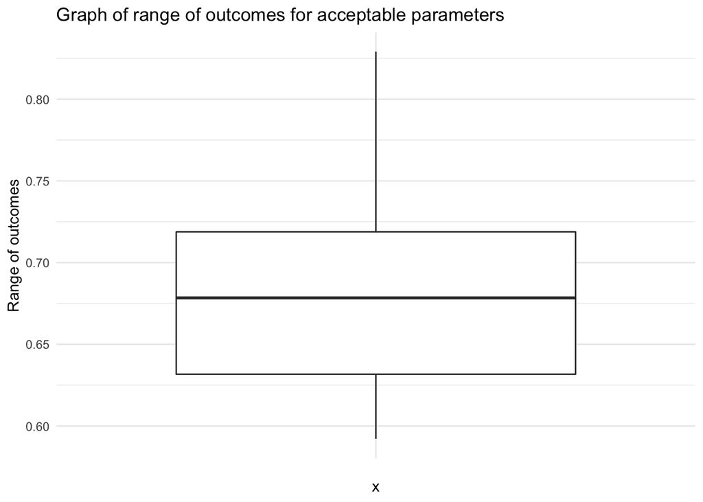

```r
#graph range of performance measures
ggplot(res_range, aes("", values))+geom_boxplot() + ggtitle("Graph of range of outcomes for acceptable parameters")+ylab("Range of outcomes") + theme_minimal()
```